# Final Project: Initial Exploratory Data Analysis (EDA)

Omer Canca, Riley Blake, ZiyuanYe

November 19 2021

## Clearing workspace

```r
# Load `tidyverse` and `dcData` packages
rm(list = ls())     # clean up your R environment
```

# load packages

```r
library(tidyverse)
library(dplyr)
library(rvest)
library(ggplot2)
library(ggformula)
```

## **Guiding Question (i.e., Research Question)**:

What is a good predictor for car and motorcycle price?

## Primary Data Source:

### Origin

URL: https://www.kaggle.com/jingbinxu/sample-of-car-data

```r
Cars <- read.csv("car_data.csv")
```

### Examining Variables:

```r
ls(Cars)
```

```
 [1] "aspiration"        "body_style"        "city_mpg"          "compression_ratio" "curb_weight"       "drive_wheels"      "engine_location"
 [8] "engine_size"       "engine_type"       "fuel_system"       "fuel_type"         "height"            "highway_mpg"       "horsepower"
[15] "length"            "make"              "num_of_cylinders"  "num_of_doors"      "peak_rpm"          "price"             "wheel_base"
[22] "width"             "X"
```

There are 22 variables include make, fuel type, aspiration, number of doors, body style, drive wheels, engine location, wheel base, length, width, height, curb weight, engine type, num of cylinders, engine size, fuel system, compression ratio, horsepower, peak rpm, city mpg, highway mpg, and price. We will mainly focus on fuel type, number of doors, number of cylinders, horsepower, and price.

#### Key Variables

Categorical Examples: make, num_of_doors, fuel_type Quantitative Examples: highway_mpg, price, city_mpg, horsepower

#### Graphing some of our key variables

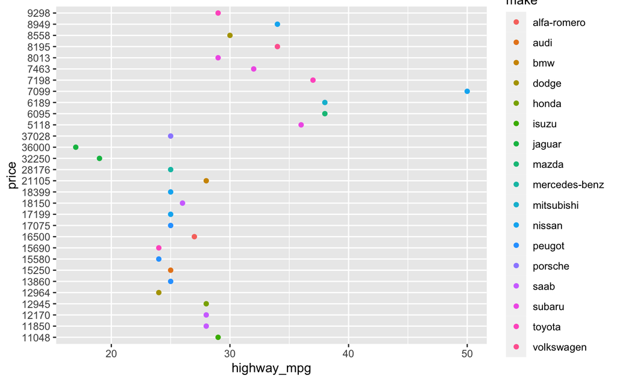

```r
CarSample <-
  Cars %>%
  drop_na()

CarSample <- Cars[sample(nrow(Cars), size=30), ]#Random Sample

ggplot(data = CarSample, aes(x = highway_mpg, y = price, color = make)) + geom_point() #highway_mpg, price, make
```

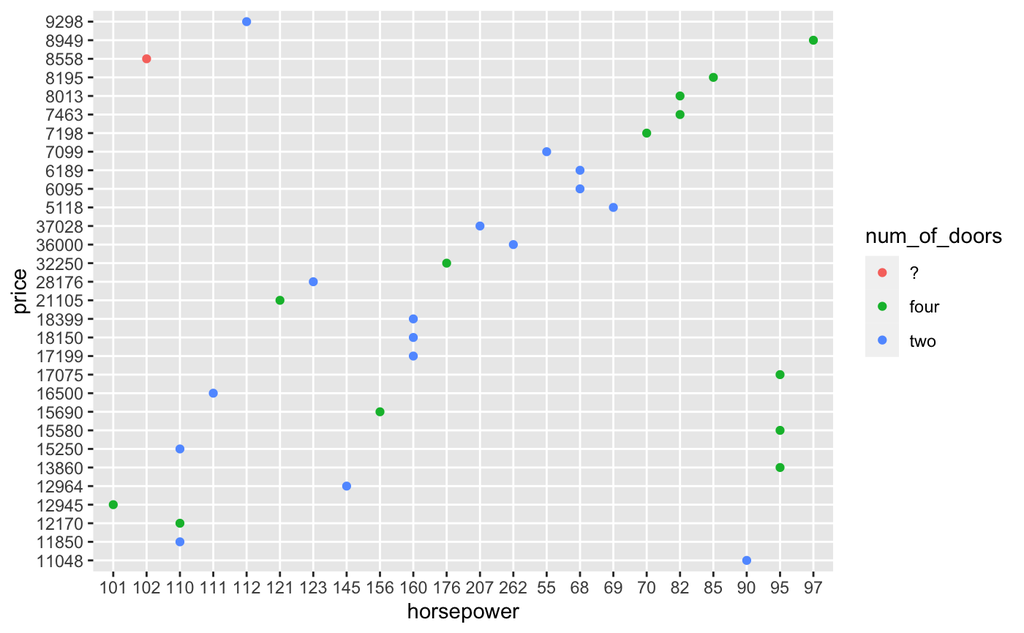

```r
ggplot(data = CarSample, aes(x = horsepower, y = price, color = num_of_doors)) + geom_point() #horsepower, price, number of doors
```

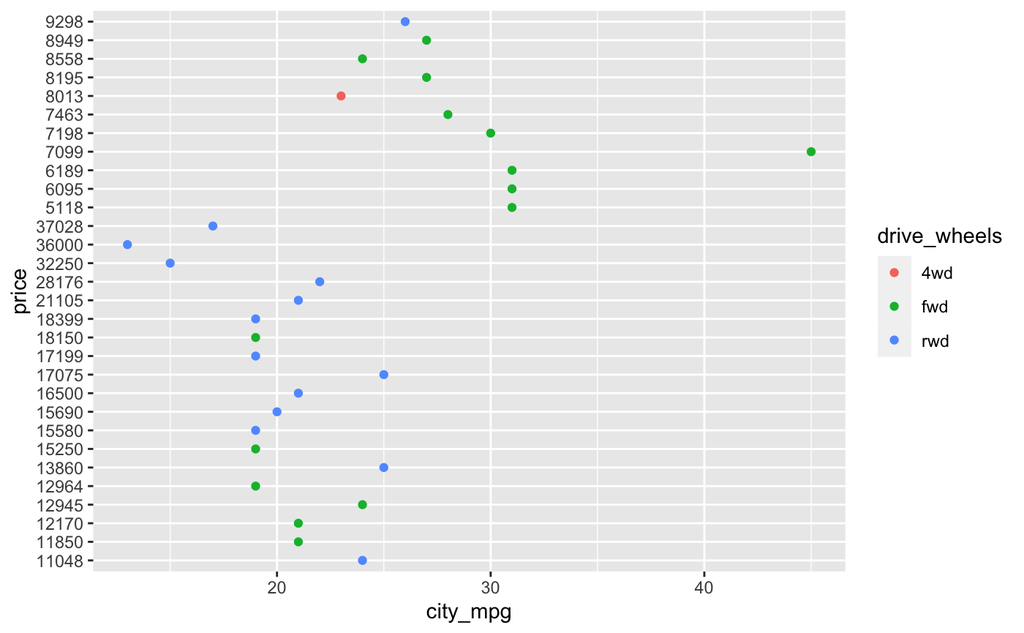

```r
ggplot(data = CarSample, aes(x = city_mpg, y = price, color = drive_wheels)) + geom_point() #city_mpg, price, drive_wheels
```

### Features that Influence Modeling Decision

```r
CarModel <- lm(price ~ highway_mpg, data = CarSample) ##sample model
summary(CarModel)
```

```
Call:
lm(formula = price ~ highway_mpg, data = CarSample)

Residuals:
    Min      1Q  Median      3Q     Max
-6646.0 -3730.5 -1553.6    47.9 18606.0

Coefficients:
            Estimate Std. Error t value Pr(>|t|)
(Intercept)  41940.6     5212.9   8.046 9.24e-09 ***
highway_mpg   -940.7      176.7  -5.324 1.15e-05 ***
---
Signif. codes:  0 ‘***’ 0.001 ‘**’ 0.01 ‘*’ 0.05 ‘.’ 0.1 ‘ ’ 1

Residual standard error: 6179 on 28 degrees of freedom
Multiple R-squared:  0.503, Adjusted R-squared:  0.4853
F-statistic: 28.34 on 1 and 28 DF,  p-value: 1.146e-05
```

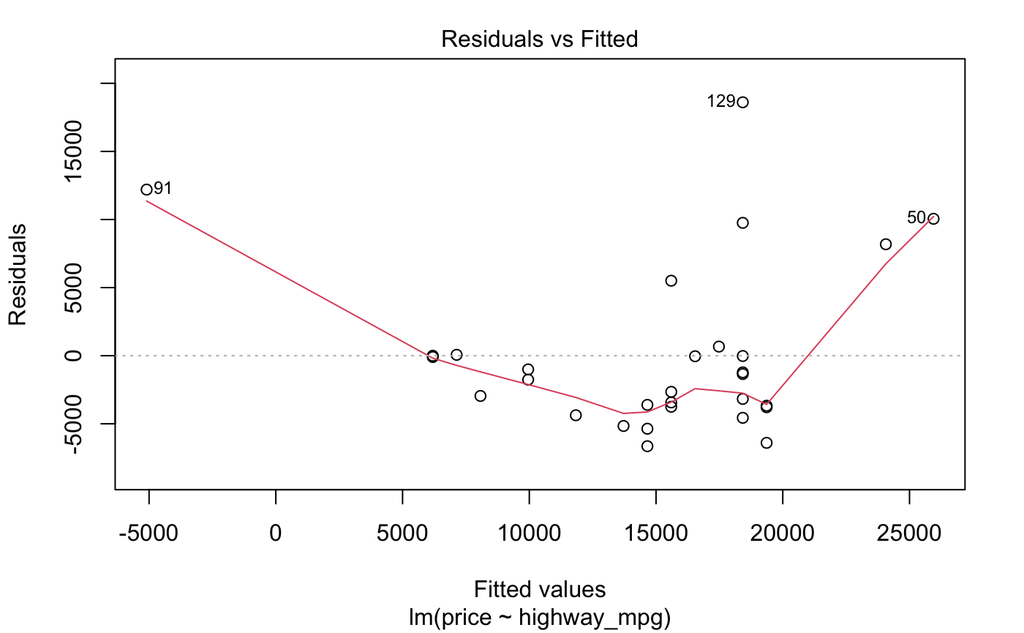

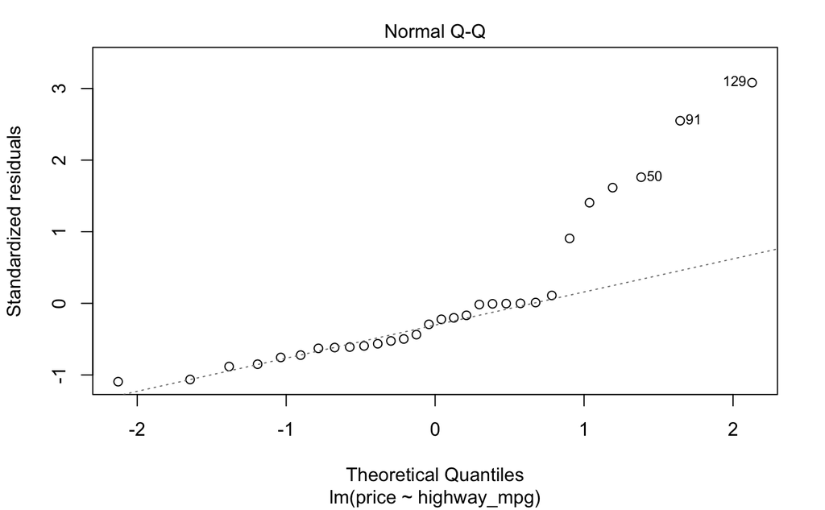

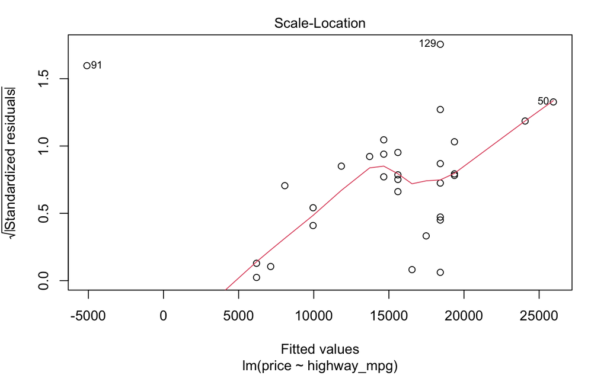

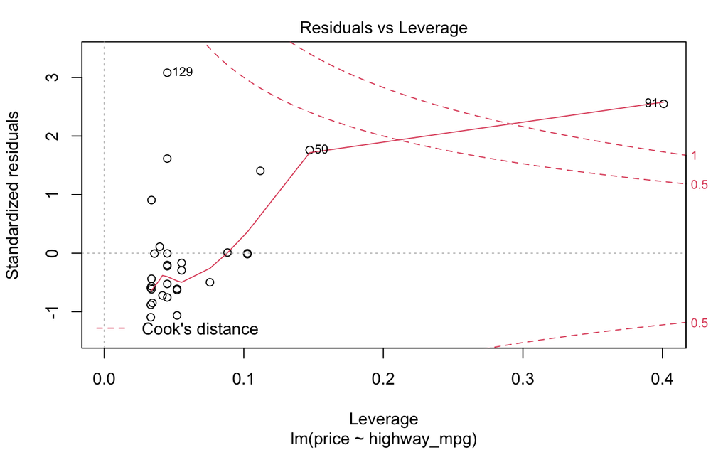

```r
plot(CarModel)
```

#### Outliers

Our plots tell us that there are a couple outliers. However, in most datasets where we are comparing prices of things, there will be a tail when the price rises. Therefore, we may have to cutoff the price at a certain point in order to account for influential points.

### Addressing our Research Question

```r
summary(CarModel)
```

```
Call:
lm(formula = price ~ highway_mpg, data = CarSample)

Residuals:
    Min      1Q  Median      3Q     Max
-6646.0 -3730.5 -1553.6    47.9 18606.0

Coefficients:
            Estimate Std. Error t value Pr(>|t|)
(Intercept)  41940.6     5212.9   8.046 9.24e-09 ***
highway_mpg   -940.7      176.7  -5.324 1.15e-05 ***
---
Signif. codes:  0 ‘***’ 0.001 ‘**’ 0.01 ‘*’ 0.05 ‘.’ 0.1 ‘ ’ 1

Residual standard error: 6179 on 28 degrees of freedom
Multiple R-squared:  0.503, Adjusted R-squared:  0.4853
F-statistic: 28.34 on 1 and 28 DF,  p-value: 1.146e-05
```

We will have to ask what else we can add in order to make the model even stronger.

## Other data source(s)

### Origin

Who: Data was obtained by Nehal Birla and 2 collaborators What: Sample of Motorcycle Data including multiple variables of Motorcycle such as selling_price, which tells us how much it sells for. Year tells us what year the motorcycle was released. When: The data was collected in 2020. Where: The data was obtained from multiple open source datasets Why: To analyze motorcycle prices How: Creators used Python

URL: https://www.kaggle.com/nehalbirla/motorcycle-dataset

```r
BIKE.DETAILS <- read.csv("BIKE DETAILS.csv")
```

```r
head(BIKE.DETAILS)
```

|  | name | selling_price | year | seller_type | owner | km_driven | ex_showroom_price |
| --- | --- | --- | --- | --- | --- | --- | --- |
| 1 | Royal Enfield Classic 350 | 175000 | 2019 | Individual | 1st owner | 350 | NA |
| 2 | Honda Dio | 45000 | 2017 | Individual | 1st owner | 5650 | NA |
| 3 | Royal Enfield Classic Gunmetal Grey | 150000 | 2018 | Individual | 1st owner | 12000 | 148114 |
| 4 | Yamaha Fazer FI V 2.0 [2016-2018] | 65000 | 2015 | Individual | 1st owner | 23000 | 89643 |
| 5 | Yamaha SZ [2013-2014] | 20000 | 2011 | Individual | 2nd owner | 21000 | NA |
| 6 | Honda CB Twister | 18000 | 2010 | Individual | 1st owner | 60000 | 53857 |

### Examining Variables:

```r
ls(BIKE.DETAILS)
```

```
[1] "ex_showroom_price" "km_driven"         "name"              "owner"             "seller_type"       "selling_price"     "year"
```

#### Key Variables

Categorical Examples: owner, name, seller_type, Model Quantitative Examples: km_driven, year, ex_showroom_price, selling_price

#### Graphing some of our key variables

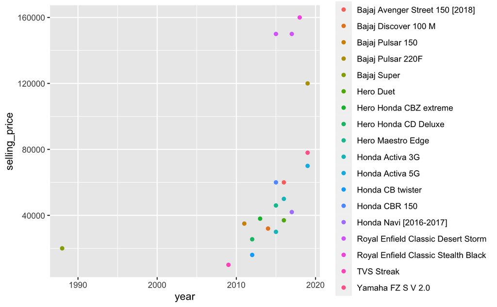

```r
BikeSample <- BIKE.DETAILS[sample(nrow(BIKE.DETAILS), size=20), ]#Random Sample

  ggplot(data = BikeSample, aes(x = year, y = selling_price, color = name)) + geom_point() #year and Price and Make
```

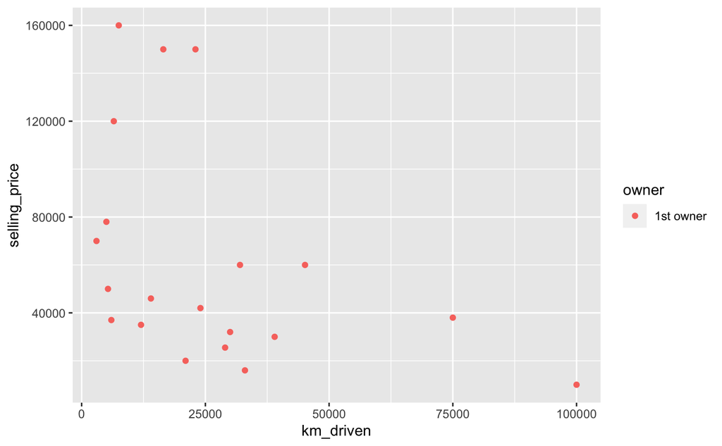

```r
ggplot(data = BikeSample, aes(x = km_driven, y = selling_price, color = owner)) + geom_point() #mileage and Price and owner
```

### Features that Influence Modeling Decision

```r
BikeModel <- lm(selling_price ~ year + km_driven, data = BIKE.DETAILS)
summary(BikeModel)
```

```
Call:
lm(formula = selling_price ~ year + km_driven, data = BIKE.DETAILS)

Residuals:
   Min     1Q Median     3Q    Max
-56808 -25893 -13000   4616 692005

Coefficients:
              Estimate Std. Error t value Pr(>|t|)
(Intercept) -9.735e+06  7.706e+05 -12.633  < 2e-16 ***
year         4.866e+03  3.825e+02  12.721  < 2e-16 ***
km_driven   -1.152e-01  3.187e-02  -3.615 0.000314 ***
---
Signif. codes:  0 ‘***’ 0.001 ‘**’ 0.01 ‘*’ 0.05 ‘.’ 0.1 ‘ ’ 1

Residual standard error: 51280 on 1058 degrees of freedom
Multiple R-squared:  0.172, Adjusted R-squared:  0.1704
F-statistic: 109.9 on 2 and 1058 DF,  p-value: < 2.2e-16
```

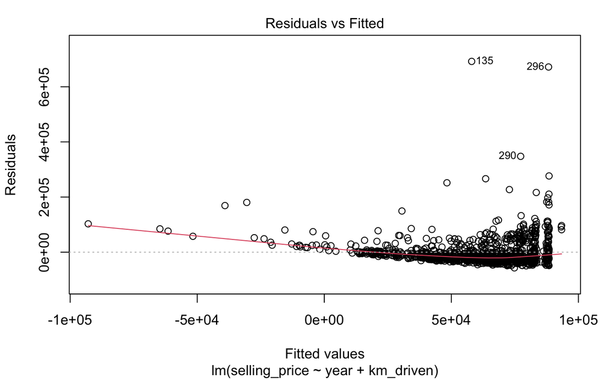

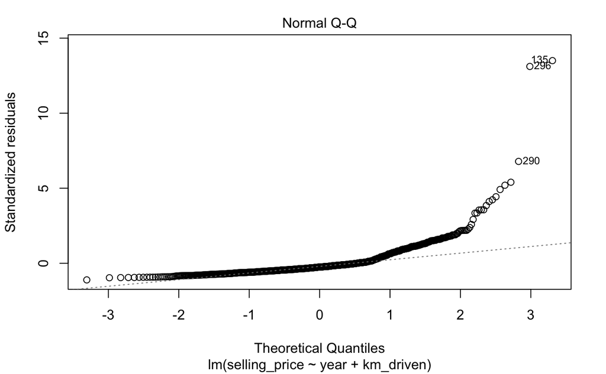

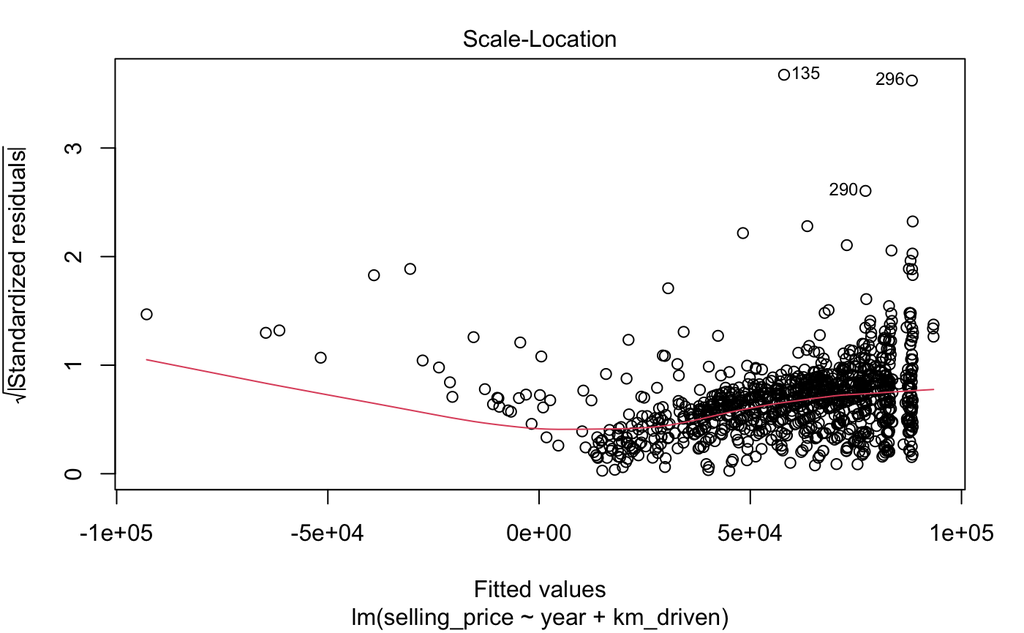

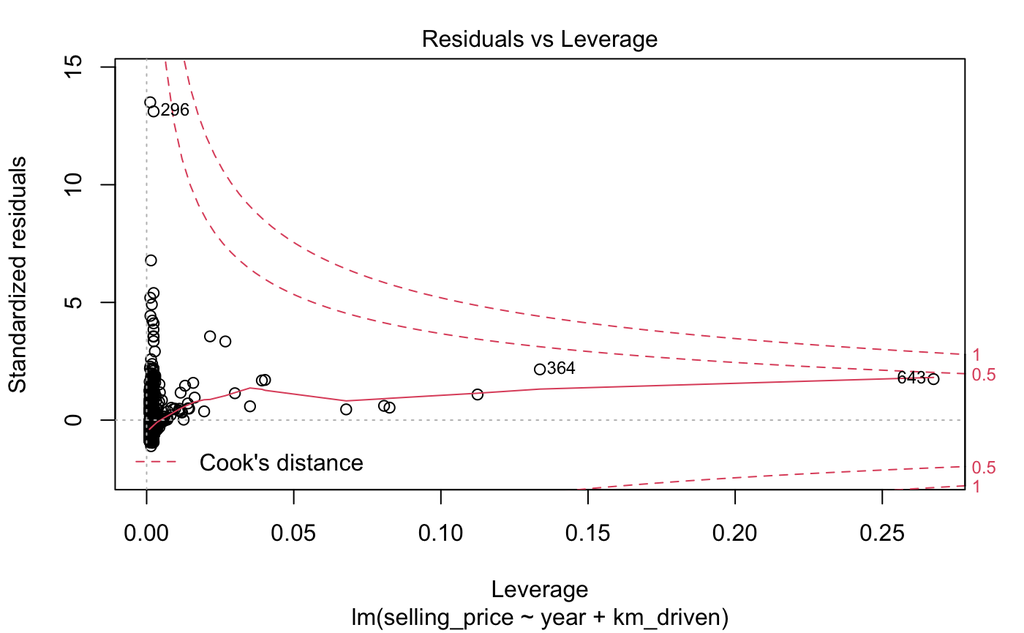

```r
plot(BikeModel)
```

#### Outliers

Our plots tell us that there are a couple outliers. However, in most datasets where we are comparing prices of things, there will be a tail when the price rises. Therefore, we may have to cutoff the price at a certain point in order to account for influential points.

#### Mutations

We will have to mutate the kilometer variable in order to create a miles variable. This will make it synchronous with the cars dataset.

### Addressing our Research Question

```r
summary(BikeModel)
```

```
Call:
lm(formula = selling_price ~ year + km_driven, data = BIKE.DETAILS)

Residuals:
   Min     1Q Median     3Q    Max
-56808 -25893 -13000   4616 692005

Coefficients:
              Estimate Std. Error t value Pr(>|t|)
(Intercept) -9.735e+06  7.706e+05 -12.633  < 2e-16 ***
year         4.866e+03  3.825e+02  12.721  < 2e-16 ***
km_driven   -1.152e-01  3.187e-02  -3.615 0.000314 ***
---
Signif. codes:  0 ‘***’ 0.001 ‘**’ 0.01 ‘*’ 0.05 ‘.’ 0.1 ‘ ’ 1

Residual standard error: 51280 on 1058 degrees of freedom
Multiple R-squared:  0.172, Adjusted R-squared:  0.1704
F-statistic: 109.9 on 2 and 1058 DF,  p-value: < 2.2e-16
```

We will have to ask what else we can add in order to make the model even stronger.